# GR 5243 Project 1

Xilin Huang

2022-09-17

# Load the History of Philosophy Dataset

```r
data<-read.csv("philosophy_data.csv")
```

# The basic information about this dataset

```r
#show the column name
colnames(data)
```

```
##  [1] "title"                     "author"
##  [3] "school"                    "sentence_spacy"
##  [5] "sentence_str"              "original_publication_date"
##  [7] "corpus_edition_date"       "sentence_length"
##  [9] "sentence_lowered"          "tokenized_txt"
## [11] "lemmatized_str"
```

In this project, we want to focus on the school. So, let’s have a look at what kind of schools we have.

```r
unique(data$school)
```

```
##  [1] "plato"           "aristotle"       "empiricism"      "rationalism"
##  [5] "analytic"        "continental"     "phenomenology"   "german_idealism"
##  [9] "communism"       "capitalism"      "stoicism"        "nietzsche"
## [13] "feminism"
```

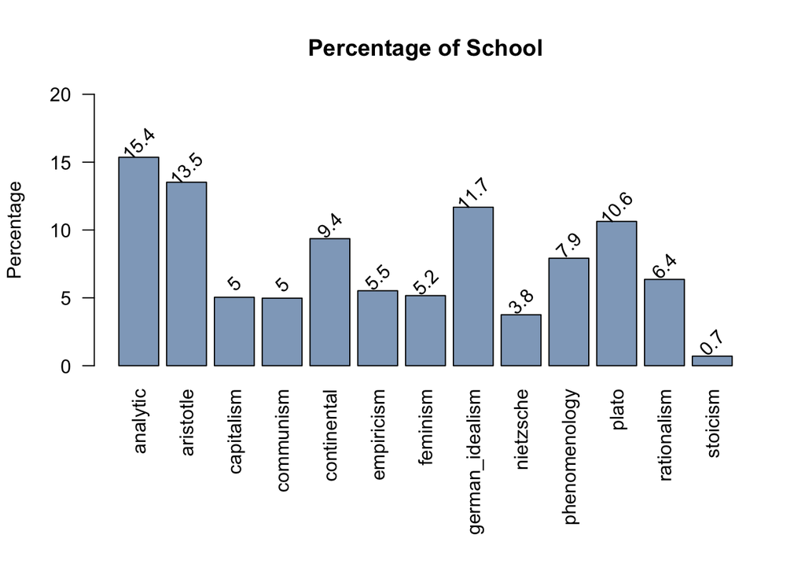

```r
par(mar = c(9,4,4,2) + 0.1)
school_perc<-t(prop.table(table(data$school))) * 100
school_perc_bp<-barplot(school_perc, ylab = "Percentage",las=2, main = "Percentage of School",col=rgb(0.2,0.4,0.6,0.6),ylim = c(0,20))
text(school_perc_bp,school_perc+1,labels = round(school_perc, 1),srt=45,)
```

From this plot, the top 5 schools of philosophy works are analytic, aristotle, german_idealism, plato and continental.

```r
#top 5 author
data%>%
  count(author)%>%
  top_n(5,n)%>%
  arrange(desc(n))
```

```
##      author     n
## 1 Aristotle 48779
## 2     Plato 38366
## 3     Hegel 22700
## 4  Foucault 15240
## 5 Heidegger 15239
```

According to this table, we can find that Aristotle and Plato composed most works in the history of philosophy.

# Compare Aristotle’s opinion with Plato’s opinion

## The number of aristotle and plato school’s works

```r
school_aristotle<-data[data$school=='aristotle',]
school_plato<-data[data$school=='plato',]
dim(school_aristotle)
```

```
## [1] 48779    11
```

```r
dim(school_plato)
```

```
## [1] 38366    11
```

```r
print(paste("The number of works belong to aristotle school is",dim(school_aristotle)[1]))
```

```
## [1] "The number of works belong to aristotle school is 48779"
```

```r
print(paste("The number of works belong to plato school is",dim(school_plato)[1]))
```

```
## [1] "The number of works belong to plato school is 38366"
```

## The number of Aristotle’s Work and Plato’s Work

```r
aristotle_work<-data%>%
  filter(grepl('Aristotle',author))
print(paste("The number of works written by Aristotle is",dim(aristotle_work)[1]))
```

```
## [1] "The number of works written by Aristotle is 48779"
```

```r
plato_work<-data%>%
  filter(grepl('Plato',author))
print(paste("The number of works written by Plato is",dim(plato_work)[1]))
```

```
## [1] "The number of works written by Plato is 38366"
```

We can conclude that from this dataset, all the Aristotle school work recorded in this dataset are from Aristotle himself. The same for Plato.

## Analyze the sentence length of each authors’ works

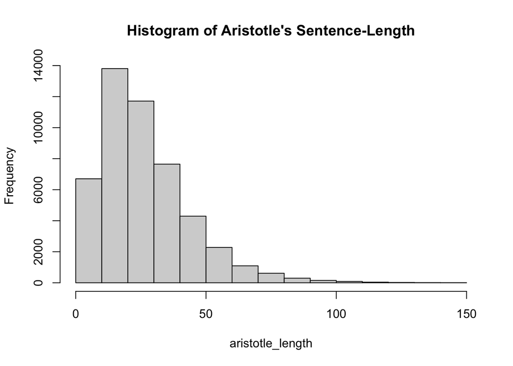

```r
aristotle_length<-str_count(school_aristotle$sentence_str,pattern=' ')
aristotle_length<-aristotle_length[aristotle_length<=150]
plato_length<-str_count(school_plato$sentence_str,pattern=' ')
hist(aristotle_length,breaks=seq(0,150,10),main = "Histogram of Aristotle's Sentence-Length")
```

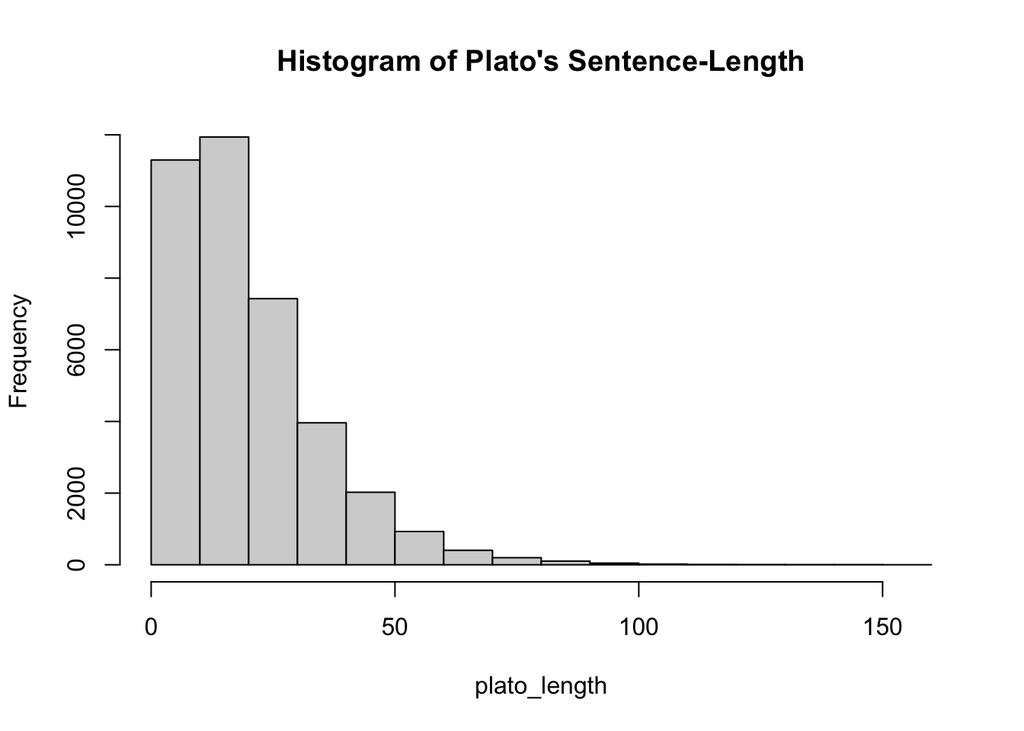

```r
hist(plato_length,breaks=15,main = "Histogram of Plato's Sentence-Length")
```

## Aristotle’s Wordcloud

```r
aris.all<-Corpus(VectorSource(aristotle_work$sentence_str))
aris.all<-tm_map(aris.all, stripWhitespace)
aris.all<-tm_map(aris.all, content_transformer(tolower))
aris.all<-tm_map(aris.all, removeWords, stopwords("english"))
aris.all<-tm_map(aris.all, removeWords, character(0))
aris.all<-tm_map(aris.all, removePunctuation)
tdm.aris.all<-TermDocumentMatrix(aris.all)
tdm.aris.tidy=tidy(tdm.aris.all)
tdm.aris.overall=summarise(group_by(tdm.aris.tidy,term),sum(count))
```

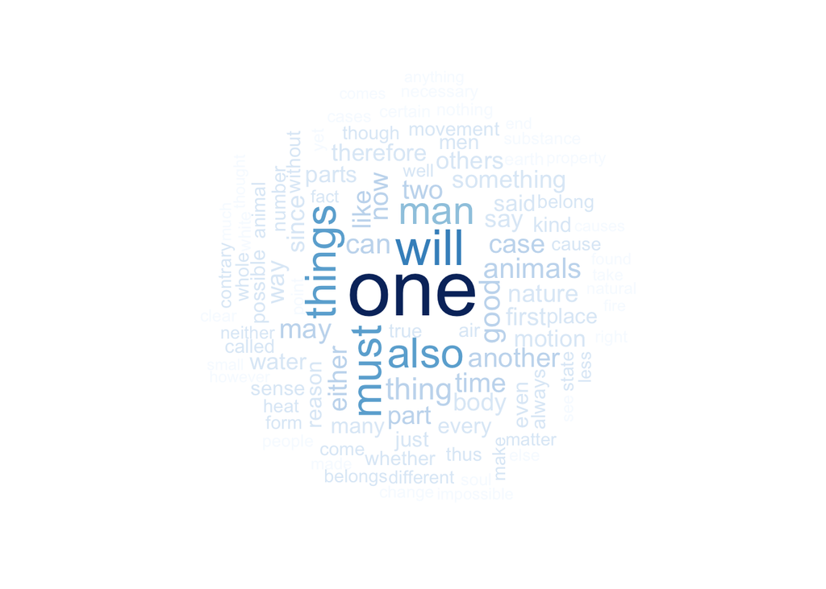

```r
wordcloud(tdm.aris.overall$term, tdm.aris.overall$`sum(count)`,
          scale=c(4,0.5),
          max.words=100,
          min.freq=1,
          random.order=FALSE,
          rot.per=0.3,
          use.r.layout=T,
          random.color=FALSE,
          colors=brewer.pal(9,"Blues"))
```

## Plato’s Wordcloud

```r
plato.all<-Corpus(VectorSource(plato_work$sentence_str))
plato.all<-tm_map(plato.all, stripWhitespace)
plato.all<-tm_map(plato.all, content_transformer(tolower))
plato.all<-tm_map(plato.all, removeWords, stopwords("english"))
plato.all<-tm_map(plato.all, removeWords, character(0))
plato.all<-tm_map(plato.all, removePunctuation)
tdm.plato.all<-TermDocumentMatrix(plato.all)
tdm.plato.tidy=tidy(tdm.plato.all)
tdm.plato.overall=summarise(group_by(tdm.plato.tidy,term),sum(count))
```

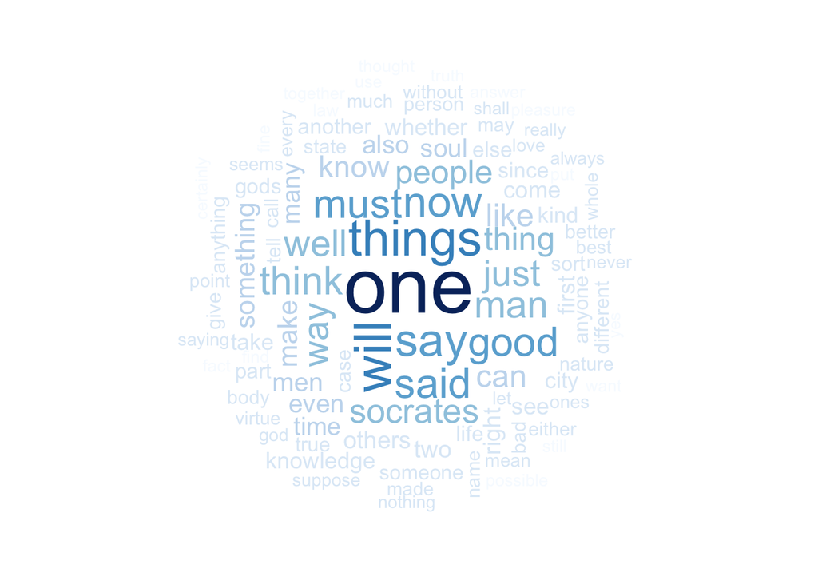

```r
wordcloud(tdm.plato.overall$term, tdm.plato.overall$`sum(count)`,
          scale=c(4,0.5),
          max.words=100,
          min.freq=1,
          random.order=FALSE,
          rot.per=0.3,
          use.r.layout=T,
          random.color=FALSE,
          colors=brewer.pal(9,"Blues"))
```

## Emotional analysis of Aristotle and Plato

```r
aris_emo<-get_nrc_sentiment(aristotle_work$sentence_str)
```

```r
plato_emo<-get_nrc_sentiment(plato_work$sentence_str)
```

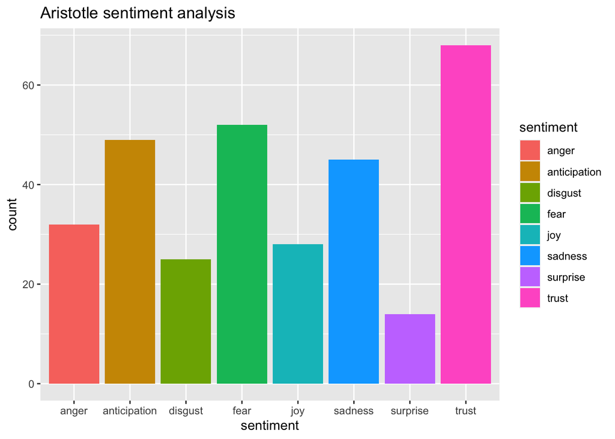

```r
par(mfrow=c(1,2))
#transpose
td<-data.frame(t(aris_emo))
#The function rowSums computes column sums across rows for each level of a grouping variable.
td_new <- data.frame(rowSums(td[2:253]))
#Transformation and cleaning
names(td_new)[1] <- "count"
td_new <- cbind("sentiment" = rownames(td_new), td_new)
rownames(td_new) <- NULL
td_new2<-td_new[1:8,]
#Plot One - count of words associated with each sentiment
quickplot(sentiment, data=td_new2, weight=count, geom="bar", fill=sentiment, ylab="count")+ggtitle("Aristotle sentiment analysis")
```

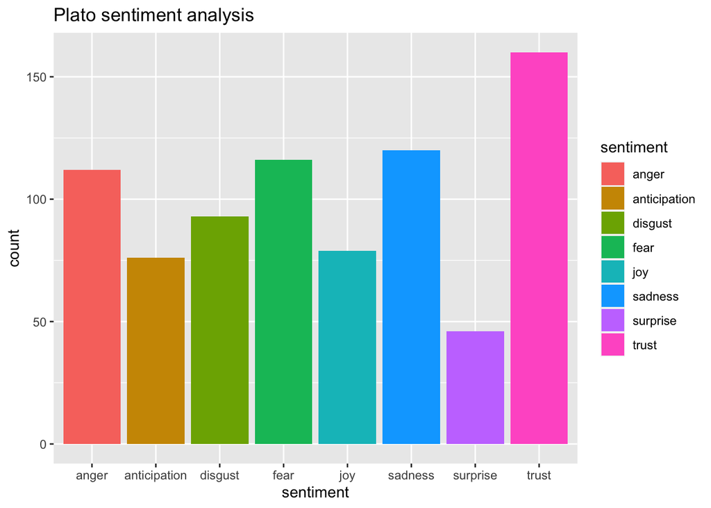

```r
#plato
#transpose
td_p<-data.frame(t(plato_emo))
#The function rowSums computes column sums across rows for each level of a grouping variable.
td_new_p<- data.frame(rowSums(td_p[2:253]))
#Transformation and cleaning
names(td_new_p)[1] <- "count"
td_new_p<- cbind("sentiment" = rownames(td_new_p), td_new_p)
rownames(td_new_p) <- NULL
td_new2_p<-td_new_p[1:8,]
#Plot One - count of words associated with each sentiment
quickplot(sentiment, data=td_new2_p, weight=count, geom="bar", fill=sentiment, ylab="count")+ggtitle("Plato sentiment analysis")
```

# Number of words

```r
aristotle_work_no<-dim(aristotle_work)[1]
sum(aristotle_length)
```

```
## [1] 1320534
```

```r
plato_work_no<-dim(plato_work)[1]
sum(plato_length)
```

```
## [1] 779335
```

# Conclusion

According to the definition, materialism is the doctrine that nothing exists except matter and its movements and modifications. The definition of idealism is that any of various system of thought in which the objects of knowledge are held to be in some way dependent on the activity of mind.

From above analysis, we can find that Aristotle cares more about the fact and Plato cares more about what you think. This matches with the definition of their works.